# Netflix Data Analysis

Alfredo Javier Arnez Valdés

2026-03-26

# Netflix Data Analysis

## 1. Introduction

This project explores a Netflix titles dataset to identify patterns in catalog composition and the distribution of titles across release years and countries. Using R, the analysis applies data cleaning techniques, exploratory data analysis, and data visualization to examine differences between movies and TV shows.

The objective is to summarize the patterns observed in the available data while recognizing the limitations of the dataset. The analysis describes historical catalog information and does not attempt to establish the causes of observed trends or infer changes in Netflix’s content strategy

## 2. Data Loading

```r
netflix <- read.csv("netflix_titles.csv")
knitr::kable(head(netflix, 10))
```

| show_id | type | title | director | cast | country | date_added | release_year | rating | duration | listed_in | description |
| --- | --- | --- | --- | --- | --- | --- | --- | --- | --- | --- | --- |
| s1 | Movie | Dick Johnson Is Dead | Kirsten Johnson |  | United States | September 25, 2021 | 2020 | PG-13 | 90 min | Documentaries | As her father nears the end of his life, filmmaker Kirsten Johnson stages his death in inventive and comical ways to help them both face the inevitable. |
| s2 | TV Show | Blood & Water |  | Ama Qamata, Khosi Ngema, Gail Mabalane, Thabang Molaba, Dillon Windvogel, Natasha Thahane, Arno Greeff, Xolile Tshabalala, Getmore Sithole, Cindy Mahlangu, Ryle De Morny, Greteli Fincham, Sello Maake … | South Africa | September 24, 2021 | 2021 | TV-MA | 2 Seasons | International TV Shows, TV Dramas, TV Mysteries | After crossing paths at a party, a Cape Town teen sets out to prove whether a private-school swimming star is her sister who was abducted at birth. |
| s3 | TV Show | Ganglands | Julien Leclercq | Sami Bouajila, Tracy Gotoas, Samuel Jouy, Nabiha Akkari, Sofia Lesaffre, Salim Kechiouche, Noureddine Farihi, Geert Van Rampelberg, Bakary Diombera |  | September 24, 2021 | 2021 | TV-MA | 1 Season | Crime TV Shows, International TV Shows, TV Action & Adventure | To protect his family from a powerful drug lord, skilled thief Mehdi and his expert team of robbers are pulled into a violent and deadly turf war. |
| s4 | TV Show | Jailbirds New Orleans |  |  |  | September 24, 2021 | 2021 | TV-MA | 1 Season | Docuseries, Reality TV | Feuds, flirtations and toilet talk go down among the incarcerated women at the Orleans Justice Center in New Orleans on this gritty reality series. |
| s5 | TV Show | Kota Factory |  | Mayur More, Jitendra Kumar, Ranjan Raj, Alam Khan, Ahsaas Channa, Revathi Pillai, Urvi Singh, Arun Kumar | India | September 24, 2021 | 2021 | TV-MA | 2 Seasons | International TV Shows, Romantic TV Shows, TV Comedies | In a city of coaching centers known to train India’s finest collegiate minds, an earnest but unexceptional student and his friends navigate campus life. |
| s6 | TV Show | Midnight Mass | Mike Flanagan | Kate Siegel, Zach Gilford, Hamish Linklater, Henry Thomas, Kristin Lehman, Samantha Sloyan, Igby Rigney, Rahul Kohli, Annarah Cymone, Annabeth Gish, Alex Essoe, Rahul Abburi, Matt Biedel, Michael Truc… |  | September 24, 2021 | 2021 | TV-MA | 1 Season | TV Dramas, TV Horror, TV Mysteries | The arrival of a charismatic young priest brings glorious miracles, ominous mysteries and renewed religious fervor to a dying town desperate to believe. |
| s7 | Movie | My Little Pony: A New Generation | Robert Cullen, José Luis Ucha | Vanessa Hudgens, Kimiko Glenn, James Marsden, Sofia Carson, Liza Koshy, Ken Jeong, Elizabeth Perkins, Jane Krakowski, Michael McKean, Phil LaMarr |  | September 24, 2021 | 2021 | PG | 91 min | Children & Family Movies | Equestria’s divided. But a bright-eyed hero believes Earth Ponies, Pegasi and Unicorns should be pals — and, hoof to heart, she’s determined to prove it. |
| s8 | Movie | Sankofa | Haile Gerima | Kofi Ghanaba, Oyafunmike Ogunlano, Alexandra Duah, Nick Medley, Mutabaruka, Afemo Omilami, Reggie Carter, Mzuri | United States, Ghana, Burkina Faso, United Kingdom, Germany, Ethiopia | September 24, 2021 | 1993 | TV-MA | 125 min | Dramas, Independent Movies, International Movies | On a photo shoot in Ghana, an American model slips back in time, becomes enslaved on a plantation and bears witness to the agony of her ancestral past. |
| s9 | TV Show | The Great British Baking Show | Andy Devonshire | Mel Giedroyc, Sue Perkins, Mary Berry, Paul Hollywood | United Kingdom | September 24, 2021 | 2021 | TV-14 | 9 Seasons | British TV Shows, Reality TV | A talented batch of amateur bakers face off in a 10-week competition, whipping up their best dishes in the hopes of being named the U.K.’s best. |
| s10 | Movie | The Starling | Theodore Melfi | Melissa McCarthy, Chris O’Dowd, Kevin Kline, Timothy Olyphant, Daveed Diggs, Skyler Gisondo, Laura Harrier, Rosalind Chao, Kimberly Quinn, Loretta Devine, Ravi Kapoor | United States | September 24, 2021 | 2021 | PG-13 | 104 min | Comedies, Dramas | A woman adjusting to life after a loss contends with a feisty bird that’s taken over her garden — and a husband who’s struggling to find a way forward. |

## 3. Data Cleaning

```r
colSums(is.na(netflix))
```

```
##      show_id         type        title     director         cast      country
##            0            0            0            0            0            0
##   date_added release_year       rating     duration    listed_in  description
##            0            0            0            0            0            0
```

```r
colSums(netflix == "", na.rm = TRUE)
```

```
##      show_id         type        title     director         cast      country
##            0            0            0         2634          825          831
##   date_added release_year       rating     duration    listed_in  description
##           10            0            4            3            0            0
```

```r
netflix$country[netflix$country == ""] <- "Unknown"
```

```r
summary(netflix)
```

```
##    show_id              type              title             director
##  Length:8807        Length:8807        Length:8807        Length:8807
##  Class :character   Class :character   Class :character   Class :character
##  Mode  :character   Mode  :character   Mode  :character   Mode  :character
##
##
##
##      cast             country           date_added         release_year
##  Length:8807        Length:8807        Length:8807        Min.   :1925
##  Class :character   Class :character   Class :character   1st Qu.:2013
##  Mode  :character   Mode  :character   Mode  :character   Median :2017
##                                                           Mean   :2014
##                                                           3rd Qu.:2019
##                                                           Max.   :2021
##     rating            duration          listed_in         description
##  Length:8807        Length:8807        Length:8807        Length:8807
##  Class :character   Class :character   Class :character   Class :character
##  Mode  :character   Mode  :character   Mode  :character   Mode  :character
##
##
##
```

## 4. Exploratory Data Analysis

```
##      type    n
## 1   Movie 6131
## 2 TV Show 2676
```

```
##    release_year    n
## 1          2018 1147
## 2          2017 1032
## 3          2019 1030
## 4          2020  953
## 5          2016  902
## 6          2021  592
## 7          2015  560
## 8          2014  352
## 9          2013  288
## 10         2012  237
```

```
## # A tibble: 10 × 2
##    country            n
##    <chr>          <int>
##  1 United States   3690
##  2 India           1046
##  3 Unknown          831
##  4 United Kingdom   806
##  5 Canada           445
##  6 France           393
##  7 Japan            318
##  8 Spain            232
##  9 South Korea      231
## 10 Germany          226
```

## 5. Visualizations

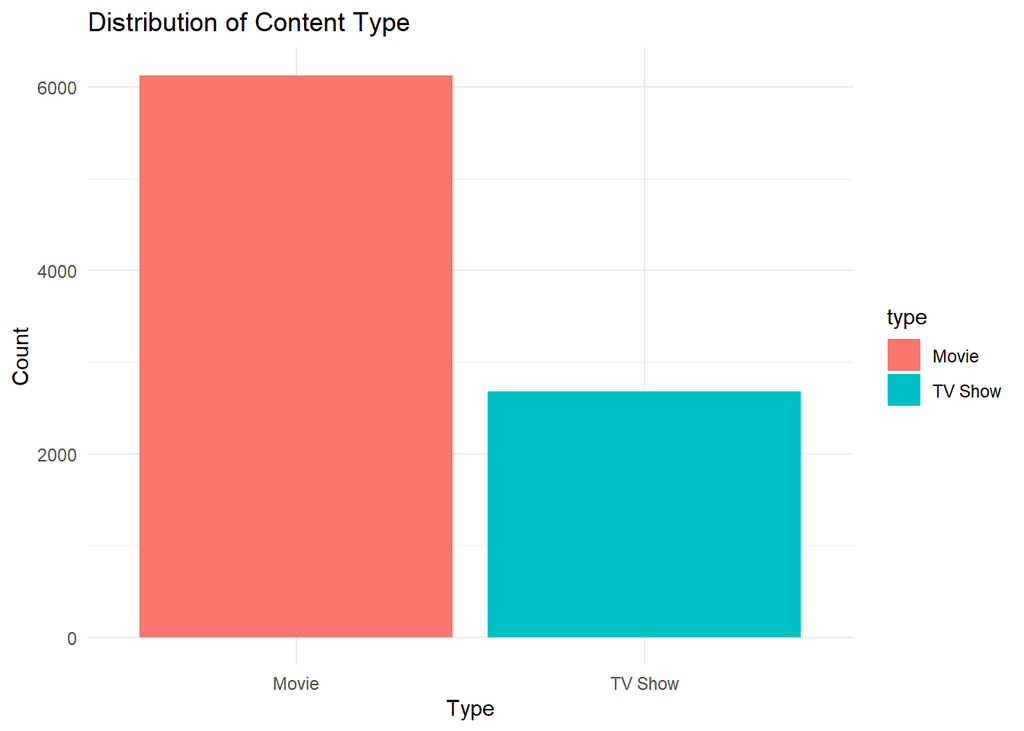

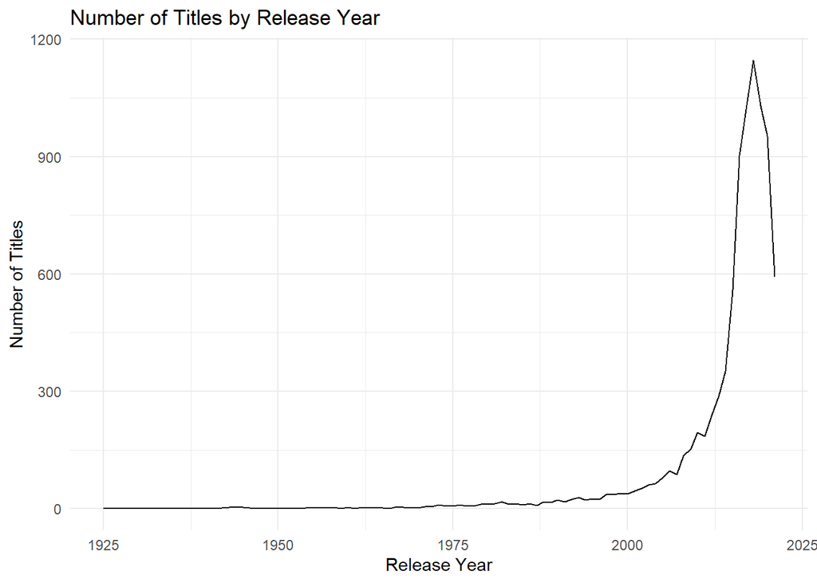

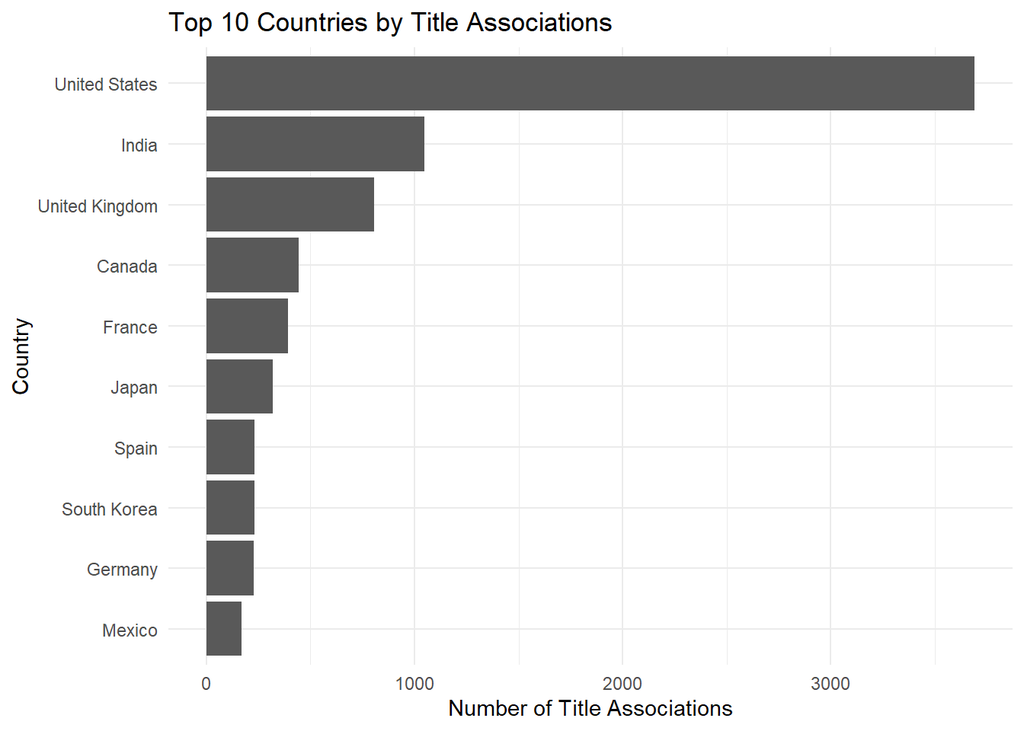

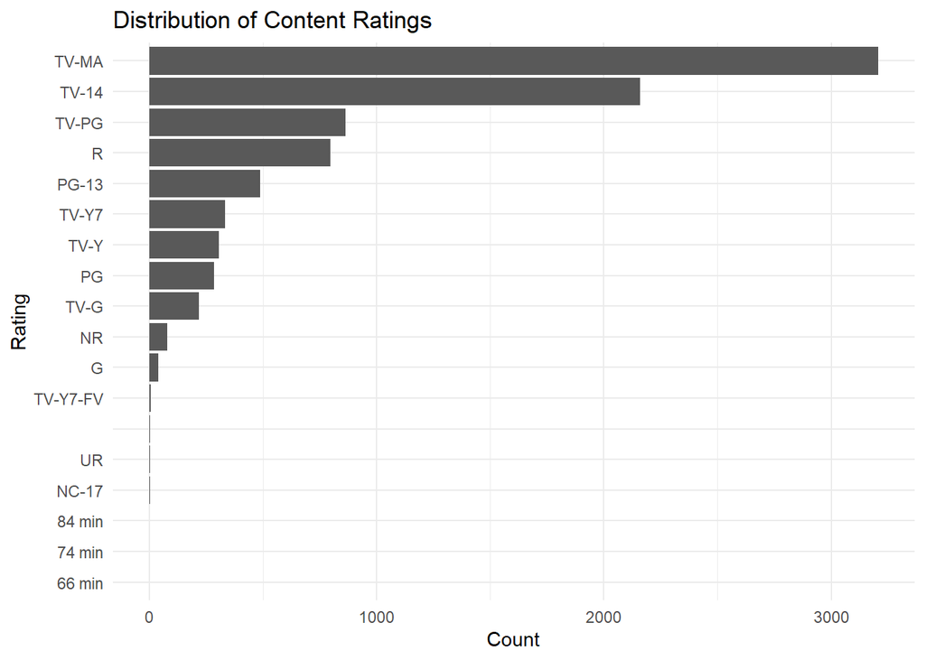

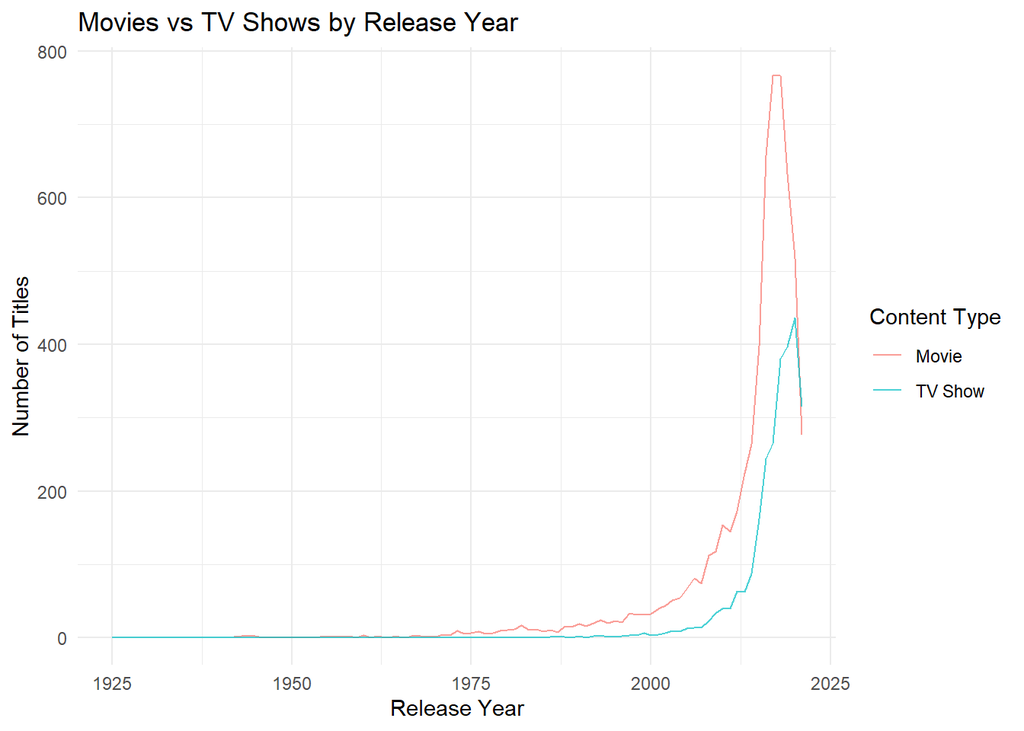

The content type distribution shows the representation of movies and TV shows in the dataset. Title counts vary across release years, with the highest counts concentrated in the late 2010s among the years displayed. Movies appear more frequently than TV shows across much of the period analyzed. The country comparison identifies the United States as the country most frequently associated with titles, followed by India and the United Kingdom, excluding records labeled as “Unknown”. Content ratings also vary in frequency across the catalog.The dataset’s latest recorded catalog addition date is September 25, 2021, so the lower counts in recent release years should not be interpreted as conclusive evidence of declining content production.. These visualizations describe the available data and do not establish the causes of the observed patterns.

## 6. Conclusions

The analysis provides an overview of the composition and distribution of titles in the Netflix dataset.

Movies represent a larger share of the catalog than TV shows. From a geographical perspective, the United States has the highest number of title-country associations, followed by India and the United Kingdom. Some records have an “Unknown” country classification, which limits the completeness of the geographical analysis.

Title counts vary across release years, with high counts during the late 2010s among the years represented. Movies appear more frequently than TV shows across much of the period analyzed. However, the dataset only records catalog additions through September 25, 2021, and the lower counts in recent release years cannot, by themselves, establish a decline in Netflix’s production or a change in its content strategy.

Overall, the findings describe patterns in a historical snapshot of the available catalog and should be interpreted in light of its temporal and data limitations.

## Limitations

This analysis has several limitations. First, some records lack country information, which may affect the completeness of geographical comparisons. Second, the dataset’s date_added field ranges from January 1, 2008, to September 25, 2021. Therefore, the dataset does not reflect additions to the Netflix catalog after that date and may not represent current catalog conditions. Finally, the analysis describes patterns in the available data and does not establish the causes behind changes in title counts or viewer preferences.